# A10 (80 points)

Olivia Martin

2022-11-29

**Instructions.** Change the author name on line 3 to be your name. Insert all requested answers. Upload in Moodle this file and a knitted file (html, doc, or pdf).

1. (2 points) What are the possible outcomes?

   The integers 2-12
2. (2 points) Conjecture what the probability distribution might be.

   This is more informed than your average conjecture because I play a lot of RPGs that roll 2d6. Seven is the most common number to roll because any number 1-6 could be included in the roll, whereas all other numbers exclude at least one (i.e., if one of the dice rolls a one then you there’s no way to get an eight), and the shape is like a symmetrical pyramid with 7 at the center. There is one way to roll a 2 or a 12, two ways to roll a 3 or an 11, three ways to roll a 4 or a 10, four ways to roll a 5 or a 9, five ways to roll a 6 or an 8, and six ways to roll a 7.
3. (6 points) Simulate this random activity 10,000 times and graph the resulting empirical probability distribution.

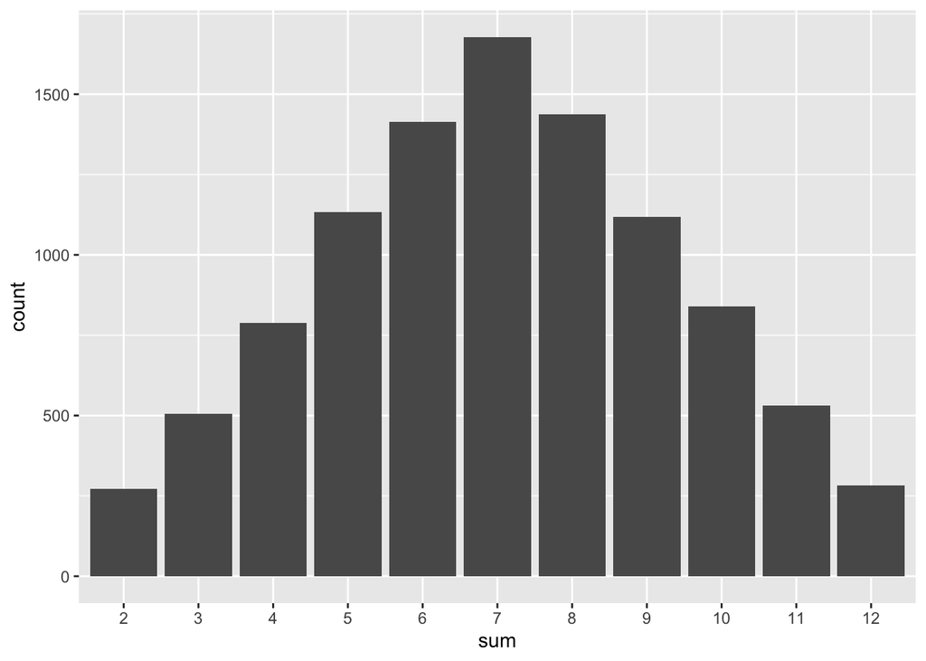

   ```r
   d6 = function(n) {
     roll = sample(c(1:6), size = n, replace = TRUE)
     sum(roll)
   }

   tibble(sum = as.factor(replicate(10000, d6(2)))) %>% ggplot(aes(x = sum)) +
     geom_bar()
   ```

4. (2 points) Describe how your conjecture compares with the simulation.

   The distribution looks exactly as I expected it to, though each equally likely pair of numbers didn’t always occur an exactly equal number of times.

**Exercise 2 (24 points).** Consider flipping a fair coin 36 times and counting the number of heads.

1. (2 points) What are the possible outcomes?

   You could potentially get any number between 0 and 36.
2. (2 points) Conjecture what the probability distribution might be.

   I’m pretty sure it’s kind of normal or pyramid-y, but I’m not sure how steep the sides are.
3. (6 points) Simulate this random activity 10,000 times and graph the resulting empirical probability distribution as a histogram.

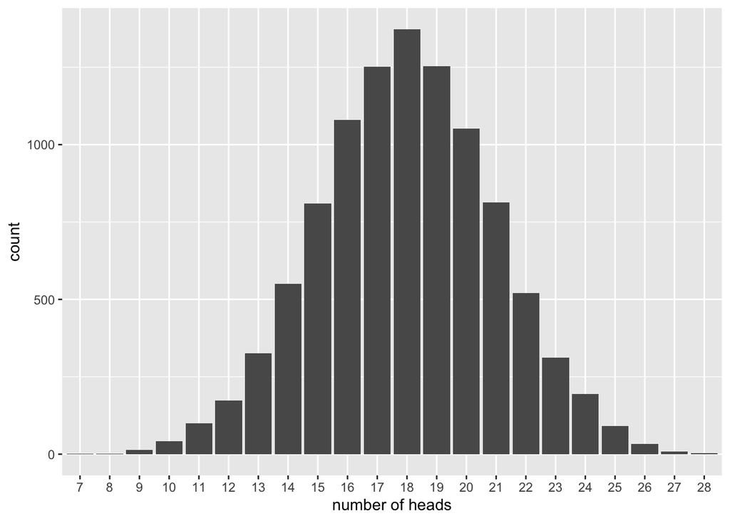

   ```r
   coin = function(n) {
     flip = sample(c(0,1), size = n, replace = TRUE)
     sum(flip)
   }

   flips = tibble(heads = (replicate(10000, coin(36))))
   flips %>% ggplot(aes(x = as.factor(heads))) +
     geom_bar() +
     xlab('number of heads')
   ```

4. (2 points) Describe how your conjecture compares with the simulation.

   I thought it might be more of an angular shape like the dice, but the normal distribution doesn’t surprise me.
5. (4 points) Provide a theoretical argument for what the mean and standard deviation should be for this random activity.

   If there’s a 50% chance to get heads on any of 36 independent flips, you should expect to get about 18 heads, so that’s your mean. The standard deviation should be $\frac{\sqrt{n}}{2}$, so with n = 36 we have a standard deviation of 3.
6. (4 points) Obtain the mean and standard deviation of your simulated data, and compare with the theoretical values.

   ```r
   summarise(flips, mean = mean(heads), sd = sd(heads))
   ```

   | mean | sd |
   | --- | --- |
   | 17.9724 | 2.973873 |

7. (4 points) Graph the histogram from part (c) with an appropriate normal distribution overlaid.

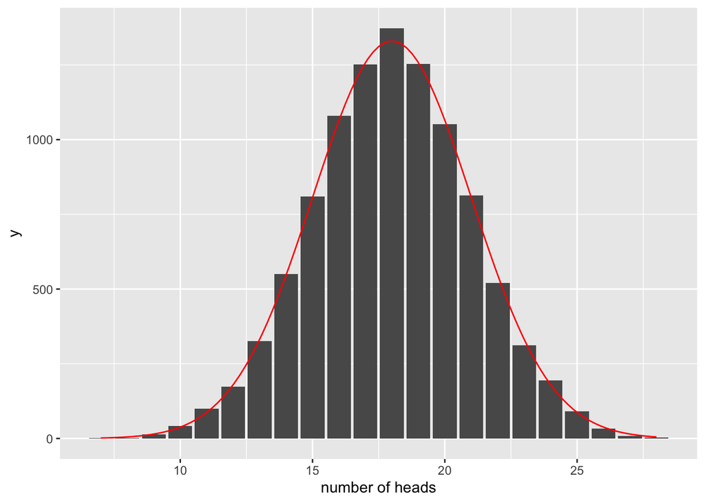

   ```r
   flips %>% ggplot(aes(x = heads)) +
     geom_bar() +
     geom_function(fun = function(x) 10000*dnorm(x, mean = 18, sd = 3), color = 'red') +
     xlab('number of heads')
   ```

**Exercise 3 (12 points).** The side lengths of a rectangle are 12.1 ± 0.3 inches by 5.6 ± 0.4 inches.

1. (2 points) What is your best estimate for the area of the rectangle? Include units!

   12.1*5.6 = 67.76 square inches
2. (2 points) Conjecture the precision of your area estimate. Include units!

   The smallest it could be is 11.8*5.2 = 61.36 square inches, and the largest it could be is 12.4*6.0 = 74.4 square inches, so 67.76 would hypothetically be correct within 6.5 square inches either way.
3. (6 points) Assume that the true side lengths are given by appropriate normal distributions. Simulate the side length and area measurements 10,000 times, and find the mean and standard deviation of the simulated areas.

   ```r
   rarea = function() {
     sidea = rnorm(1, mean = 12.1, sd = 0.3)
     sideb = rnorm(1, mean =  5.6, sd = 0.4)
     tibble(area = sidea * sideb)
   }
   sdata5 = bind_rows(rerun(10000, rarea()))
   sdata5 %>% summarise(mean(area), sd(area))
   ```

   | mean(area) | sd(area) |
   | --- | --- |
   | 67.65261 | 5.093395 |

4. (2 points) Compare the simulation results with your answers to (a) and (b).

   My conjecture for the area was very close. I figured that I would probably overestimate the precision, but the simulation standard deviation was close enough that I’m not bothered.

**Exercise 4 (10 points).** The weights of adult males are claimed to be normally distributed with mean 176 pounds and standard deviation 22 pounds. The weights of adult females are claimed to be normally distributed with mean 121 pounds and standard deviation 11 pounds.

1. (2 points) State your sex and weight in pounds. (You can make up your answers–unless completely outlandish, how am I to know?)

   I’m AFAB (assigned female at birth) and last I checked about 165 pounds.
2. (4 points) Calculate your z-score, and state its meaning in words.

   According to the given statistics, my z-score is (165-121)/11 = 4, which would seem to indicate that I am one of the heaviest women on earth. That being obviously false, I looked up the CDC data. The latest I found was published in 2018, and it gave the mean weight in pounds for women 20 and above as 171 pounds. Assuming 11 pounds as the standard deviation, this gives me a z-score of (165-171)/11 = -0.55, making me slightly lighter than the average American woman 20 years or older.
3. (4 points) What percentage of adults of your sex weigh no more than you do?

   ```r
   pnorm(-0.5454545)
   ```

   ```
   ## [1] 0.2927205
   ```

   According to the CDC average, about 29% of adult women weigh no more than me.

**Exercise 5 (22 points).** Answer the following reading questions (Read) and problems (Prob) from *Statistical Modeling: End-of-Chapter Exercises* by Daniel Kaplan. You should not need to refer to Kaplan, although his multiple choice answers to some problems may provide greater confidence when coming up with your answers.

*Prob 11.12 (4 points).** Experience shows that the number of cars entering a park on a summer’s day is approximately normally distributed with mean 200 and variance 900. Find the probability that the number of cars entering the park is less than 195.

```r
pnorm(195, mean = 200, sd = 300)
```

```
## [1] 0.4933513
```

```r
pnorm(-1, mean = 200, sd = 300)
```

```
## [1] 0.2514289
```

**Prob 11.21 (14 points).** Ralph’s bowling scores in a single game are normally distributed with a mean of 120 and a standard deviation of 10.

1. (4 points) He plays 5 games. What is the mean and standard deviation of his total score?

   Mean: 600

   Standard deviation: 22.36
2. (4 points) What is the mean and standard deviation of his average score for the 5 games?

   Mean: 120

   Standard deviation: 4.47

Lucky Lolly bowls games with scores randomly distributed with a mean of 100 and standard deviation of 15.

3. (1 point) What is the z-score of 150 for Lolly?

   ```r
   (150-100)/15
   ```

   ```
   ## [1] 3.333333
   ```

4. (1 point) What is the z-score of 150 for Ralph?

   ```r
   (150-120)/10
   ```

   ```
   ## [1] 3
   ```

5. (1 point) Is Lolly or Ralph more likely to score over 150?

   Ralph
6. (1 point) What is the z-score of 130 for Lolly?

   ```r
   (130-100)/15
   ```

   ```
   ## [1] 2
   ```

7. (1 point) What is the z-score of 130 for Ralph?

   ```r
   (130-120)/10
   ```

   ```
   ## [1] 1
   ```

8. (1 point) Is Lolly or Ralph more likely to score over 130?

   Ralph

**Prob 11.22 (4 points).** Jim scores 700 on the mathematics part of the SAT. Scores on the SAT follow the normal distribution with mean 500 and standard deviation 100. Julie takes the ACT test of mathematical ability, which has mean 18 and standard deviation 6. She scores 24. If both tests measure the same kind of ability, who has the higher score? Explain.

Jim has a z-score of (700-500)/100 = 2 and Julie has a z-score of (24-18)/6 = 1, so Jim has the higher score.